# ivspatial — user guide (R)

Nonparametric tests of spatial independence on neighbourhood graphs, version 1.0.0. Companion software to E. Ashtari Nezhad, *A nonparametric test of spatial independence on neighbourhood graphs*.  
Install: `remotes::install_github("emaad7/ivspatial-r")` · Source: github.com/emaad7/ivspatial-r · Python version: github.com/emaad7/ivspatial

## 1. What the package does

`ivspatial` tests whether the values of a variable observed at spatial units — cells of a grid, polygons such as counties, irregularly located points, or nodes of a network — are independent and identically distributed (i.i.d.) across the units. The tests are **rank based and exact**: under independence the P-value is valid for every sample size, every graph and every continuous distribution, with no weight matrix, bandwidth or model to choose. The package reports

- the P-value of the proposed **combined test C4** and of its four components: **T_V(4,3)**, which sees dependence among a site and two of its neighbours, including dependence that is invisible in every pair; **T_V(4,2)**, pairs with finely resolved tails; **RM**, the Moran statistic of the ranks (level); and **RS**, the Moran statistic of the squared ranks (scale);
- asymptotic P-values from the explicit weighted chi-square limits;
- seven **standardized features**, which tell whether the dependence is in the level, in the scale or between neighbours;
- **maps** of local feature contributions, which show where the dependence occurs;
- a **data-driven choice of the resolution**, statistics at **several spatial lags**, **screening** of many variables with false discovery rate control, and tests for **regression residuals**.

## 2. Two ways to use it

**Without programming: the window**  
Open a file, define the neighbourhood graph, pick a variable, press *Run test*.

**With code**  
`spatial_test(x, graph)` in R scripts and R Markdown.

| Task | Window | R |
| --- | --- | --- |
| Build the graph | Neighbourhood graph box, *Build graph* | `knn_graph, delaunay_graph, lattice_graph, polygon_graph, graph_from_edges` |
| Test one variable | choose *Variable*, *Run test* | `spatial_test(x, g)` |
| Screen many variables | tick *test all* | `screen_variables(df, g)` |
| Residuals of a regression | tick *test OLS residuals*, select regressors | `residual_test(y, X, g)` |
| Data-driven resolution, lags | *Resolution* auto, *Lags* 2 | `resolution="auto", lags=2` |
| Maps | *Map* | `local_features(x, g)` |
| Null distribution | Null distribution tab | `null_limit(g, d, s)` |

## 3. Installation

```
install.packages("remotes")
remotes::install_github("emaad7/ivspatial-r")
# or, from the source file:  install.packages("ivspatial_1.0.0.tar.gz", repos = NULL, type = "source")
```

The package needs `Matrix` (included with R) and `shiny` (installed automatically) for the window. Optional: `deldir` for Delaunay graphs, `sf` and `spdep` for polygon files, `readxl` for Excel files.

## 4. Preparing your data

- **Points or grid cells:** a CSV, TXT or Excel file with **one row per site**; columns for the coordinates (or the row and column indices of a grid) and for the variables. A first row with names is recommended.
- **Polygons:** a shapefile (`.shp` with its `.dbf` and `.shx`) or a GeoJSON file; the numeric attributes are the variables.
- **Networks or your own graph:** the table of variables plus an edge list, a CSV file with two columns of site numbers (1 = first row of the table).
- **No missing values** at the sites used: remove incomplete sites before building the graph. At least 20 sites; a few hundred give the most informative results.
- The test is applied to the values you give. A smooth trend (for example along a field or a coast) is itself a departure from i.i.d.; to test for dependence beyond a trend, test the residuals (Section 11).

Examples: `mercer_hall_wheat.csv` (grain and straw yields of 500 plots on a 20 × 25 grid; columns `row`, `col`) and `baltimore_houses.csv` (211 house sales with coordinates `X`, `Y`, price and characteristics); in R, `data(mercer_hall)` and `data(baltimore)`.

## 5. The neighbourhood graph

The neighbourhood of a site is the site and its neighbours. The graph is part of the hypothesis being tested: it says which sites are considered close. Common choices:

| Data | Graph | Typical choice |
| --- | --- | --- |
| points | **k nearest neighbours** | k = 4 to 6; each site has the same number of neighbours |
| points | **Delaunay triangulation** | the contiguity of the Voronoi cells of the points; about 6 neighbours |
| points | **distance band** | all sites within a distance; check that few sites are isolated |
| grid | **rook** or **queen** contiguity | rook (4 neighbours) unless diagonal neighbours matter |
| polygons | **queen** (shared vertex) or **rook** (shared edge) | queen |
| network | **edge list** | the links of the network |

The report states the number of sites and the mean, minimum and maximum number of neighbours; isolated sites contribute nothing. For dependence that reaches beyond immediate neighbours use **lags** (Section 10) rather than very large neighbourhoods.

## 6. The window (GUI)

Press **Run test**. The report can be saved as text, the results as CSV and the local features as CSV. The **Map** tab draws the ranks of the variable and its local level and scale features; the **Null distribution** tab gives the weighted chi-square limit of T_V(d, s) on the current graph; the **User guide** tab shows this guide.

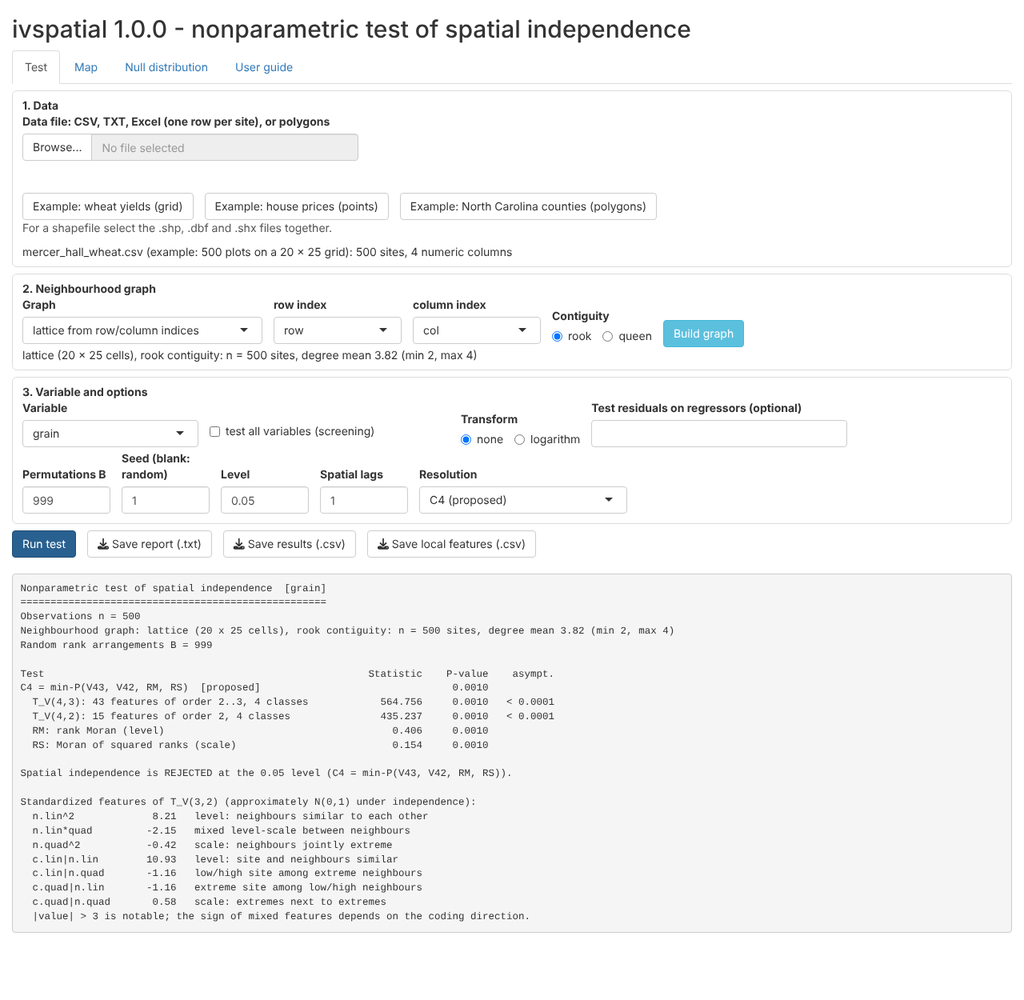

## 7. R code

```
library(ivspatial)
g <- lattice_from_indices(mercer_hall$row, mercer_hall$col, "rook")
res <- spatial_test(mercer_hall$grain, g, seed = 1, label = "grain")
res                                   # the report below
res$p_value; res$reject               # P-value of C4 and the decision
res$components                        # data frame of the four components
res$features                          # standardized features
as.data.frame(res)                    # one row, for collecting results

g <- knn_graph(cbind(baltimore$X, baltimore$Y), k = 4)  # or delaunay_graph() (package deldir)
spatial_test(log(baltimore$PRICE), g, seed = 1)
residual_test(log(baltimore$PRICE), baltimore[, c("NROOM", "NBATH", "SQFT", "AGE")], g, seed = 1)

# polygons (package sf); here the North Carolina counties shipped with sf
nc <- read_polygons(system.file("shape/nc.shp", package = "sf"))
gq <- polygon_graph(nc, "queen")
nc$SIDR79 <- 1000 * nc$SID79 / nc$BIR79
spatial_test(nc$SIDR79, gq, seed = 1)
screen_variables(sf::st_drop_geometry(nc), gq, columns = c("SID74", "SID79"), seed = 1)

# your own graph: build_graph(data, "edges", edges = "edges.csv"), graph_from_edges(i, j),
# or graph_from_neighbors(nb) for an spdep nb object

spatial_test(log(baltimore$PRICE), g, resolution = "auto", lags = 2, seed = 1)
map_local(mercer_hall$grain, lattice_graph(20, 25))     # maps of the local features
null_limit(g, d = 4, s = 2, value = 35)                 # null limit of T_V(4,2)
```

To test many variables on the same graph, `reference_table(g)` computes the random rank arrangements once and can be passed to `spatial_test(..., reference = ref)`; `screen_variables` does this automatically.

## 8. Reading the output

```
Nonparametric test of spatial independence  [grain]
====================================================
Observations n = 500
Neighbourhood graph: lattice (20 x 25 cells), rook contiguity: n = 500 sites, degree mean 3.82 (min 2, max 4)
Random rank arrangements B = 9999

Test                                                      Statistic    P-value    asympt.
C4 = min-P(V43, V42, RM, RS)  [proposed]                                0.0001
  T_V(4,3): 43 features of order 2..3, 4 classes            564.756     0.0001   < 0.0001
  T_V(4,2): 15 features of order 2, 4 classes               435.237     0.0001   < 0.0001
  RM: rank Moran (level)                                      0.406     0.0001
  RS: Moran of squared ranks (scale)                          0.154     0.0001

Spatial independence is REJECTED at the 0.05 level (C4 = min-P(V43, V42, RM, RS)).

Standardized features of T_V(3,2) (approximately N(0,1) under independence):
  n.lin^2             8.21   level: neighbours similar to each other
  n.lin*quad         -2.15   mixed level-scale between neighbours
  n.quad^2           -0.42   scale: neighbours jointly extreme
  c.lin|n.lin        10.93   level: site and neighbours similar
  c.lin|n.quad       -1.16   low/high site among extreme neighbours
  c.quad|n.lin       -1.16   extreme site among low/high neighbours
  c.quad|n.quad       0.58   scale: extremes next to extremes
  |value| > 3 is notable; the sign of mixed features depends on the coding direction.
```

- **C4** is the proposed test. A P-value below the level means that the values are not i.i.d. across the sites. All P-values in the second column are exact; the smallest possible value is 1/(B + 1), shown as 0.0001 for B = 9999.
- The **components** show which aspect carries the evidence: T_V(4,3) dependence among a site and two neighbours; T_V(4,2) pairs with resolved tails; RM the level; RS the scale. The **asymptotic** P-values use the weighted chi-square limit of the paper; they agree with the exact ones in large samples.
- The **standardized features** are approximately standard normal under independence. Here `c.lin|n.lin` is about 11 and `n.lin^2` about 8: plots resemble their neighbours in level, while the scale features are small. The sign of the mixed features (`c.lin|n.quad`, ...) changes if the variable is recoded in the opposite direction; the other features do not.

## 9. Maps of local features

Every feature is a scaled sum of local contributions, one per site, each with mean 0 and variance 1 under independence. Mapping them shows where a feature receives its contribution, much as local indicators of spatial association decompose Moran's I. Red marks sites that agree with their neighbours in level (level feature) or that are extreme together with their neighbours (scale feature). The maps are descriptive: the local values are dependent and are not tested one by one.

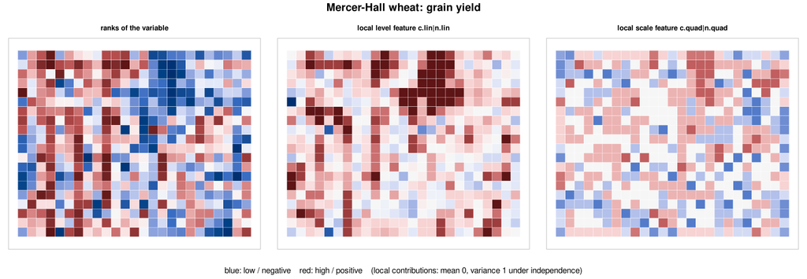

## 10. Data-driven resolution and spatial lags

**Resolution.** C4 uses four classes and orders two and three, a choice that is close to the best against level and higher-order dependence. With `resolution = "auto"` the data choose among T_V(d, s), d = 2 to 6, s = 2, 3, by the minimum-P rule; the selection is repeated in every random rank arrangement, so the P-value is exact after selection, and the report states the resolution chosen. `"schwarz"` uses a penalized choice that prefers simple statistics; it is more powerful when the dependence is low-dimensional and weaker against dependence in the tails.

**Lags.** With `lags = 2` the components are also computed for the neighbours at graph distance two and all are combined by the minimum-P rule; use it when dependence may reach beyond immediate neighbours.

## 11. Residuals of regressions

`residual_test(y, X, g)` tests the OLS residuals of y on the columns of X (an intercept is added). With exogenous regressors — including coordinates, trend surfaces and fixed effects — the tests remain valid without any correction. They are not valid for spatial-lag models, in which y is regressed on its spatially lagged values; use a model-based bootstrap there.

## 12. Troubleshooting

- **"missing or non-finite values"**: remove the incomplete sites and build the graph for the remaining ones.
- **"duplicate coordinates"** (Delaunay): several sites at the same location; use k nearest neighbours or add a tiny jitter.
- **Isolated sites**: a distance band that is too small, or islands among polygons; they contribute nothing.
- **Slow**: the reference table is computed once per graph; B = 999 is enough for a first look, B = 9999 for reporting. Order three on very large graphs takes longer; asymptotic P-values of order three are skipped for very large graphs.
- **Polygons do not touch**: contiguity is detected from shared vertices; for boundaries digitized independently, build the graph in a GIS (or with `spdep::poly2nb(..., snap = )`) and pass it with `graph_from_neighbors` or as an edge list.

## 13. Reference and citation

Ashtari Nezhad, E. (2026). A nonparametric test of spatial independence on neighbourhood graphs. Manuscript.  
Ashtari Nezhad, E. (2026). ivspatial: nonparametric tests of spatial independence. R package version 1.0.0. https://github.com/emaad7/ivspatial-r